# Flavor Text of Middle Earth: Finding flavor texts in a trilogy of books.

Ben Keel

2023-06-26

[figure not shown]

In this document, I walk through how I took the web-scraped flavor text of *Magic: The Gathering*’s “Lord of the Rings: Tales of Middle Earth” card set and found their chapter location. I used the graph at the end to then place each tab manually in a 3D model.

## Data imports:

Used a combination of tidyverse and tm for this project, so here are those packages:

```r
library(tidyverse)
library(readr)
library(tidyverse)
library(knitr)
library(dplyr)
library(ggplot2)
library(stringi)

library(tm)

options(scipen = 999)

g <- glimpse
```

## Data Needs

Ultimate data needs columns:

- Card name
- Card color
- Quote Text (Verbatim)
- Quote Text (Clean)
- Book
- Chapter of Book
- Sentence before
- Sentence after (stretch goal)

Data scraped from Scryfall:

- Card name
- Card cost
- Card color
- Quote Text (Verbatim)

```r
ft <- read_csv("scryfall_extract.csv")

g(ft)
```

```
## Rows: 462
## Columns: 4
## $ Text          <chr> "Wormtongue bared his teeth; and then with a hissing bre…
## $ cardColorList <chr> "W", "W", "W", "W", "W", "W", "W", "W", "W", "W", "W", "…
## $ card_name     <chr> "Banish from Edoras", "The Battle of Bywater", "Bill the…
## $ cost          <chr> "{4}{W}", "{1}{W}{W}", "{3}{W}", "{2}{W}", "{1}{W}", "{1…
```

Cleaning data to remove all odd quotes. Created a truncated quote column of the first 18 characters, the length of Boromir’s “Farewell, Aragorn!” to check for more matches and avoid the pitfalls of paraphrasing.

```r
ft_clean <- ft%>%
  filter(!(is.na(Text)))%>%
  filter(!duplicated(Text))%>%
  mutate(text_clean = stri_replace_all_regex(Text,
                                             pattern = c("“", "”", "—(.+)"),
                                             replacement = c(""),
                                             vectorize=FALSE),
         text_abbr = substring(text_clean, 1, 18),
         book = NA,
         chapter = NA)
```

#### LOTR Book Import

Imported the three files obtained from @jblazzy’s repo.

```r
import_txt_files <- function(folder_path, abbr) {
  file_list <- list.files(folder_path, pattern="\\.txt$", full.names=TRUE)

  imported_data <- list()

  for (i in seq_along(file_list)) {
    variable_name <- paste0(abbr, i)
    file_path <- file_list[i]
    file_data <- readLines(file_path)
    imported_data[[variable_name]] <- file_data
  }

  return(imported_data)
}

fellowship <- import_txt_files("./fellowship-chapters", "fs")
twotowers <- import_txt_files("./twotowers-chapters", "tt")
return <- import_txt_files("./return-chapters", "rk")
```

#### Bad attempts

Attempted to use a match(), but this didn’t work. I opted to do a loop and lapply() method instead, in the next block.

```r
#doesn't work
ft_clean$book <- ifelse(match(ft_clean$book, fellowship), "fs",
                        ifelse(match(ft_clean$book, twotowers), "tt",
                          ifelse(match(ft_clean$book, return), "rk", NA)))
```

Defined a function that loops through each flavor text observation and checked using grepl(), which works for half of the items. This is good progress, but it means my initial cleaning was not enough, and I need to do something more to clean the text.

```r
find_txt_match <- function(textQuote) {
  #loop through the two towers text and find the location of any match
  chapter <- ""
  print(textQuote)
  for (i in 1:length(fellowship)){
        if (grepl(textQuote, fellowship[i])) {
      chapter <- names(fellowship[i])
    }
  }
  if (chapter == ""){
    for (i in 1:length(twotowers)) {
      if (grepl(textQuote, twotowers[i])) {
        chapter <- names(twotowers[i])
      }
    }
  }
  if (chapter == "") {
        for (i in 1:length(return)) {
      if (grepl(textQuote, return[i])) {
        chapter <- names(return[i])
      }
    }
  }
  print(chapter)
  return(chapter)
}

ft_clean$chapter <- lapply(ft_clean$text_abbr, FUN = find_txt_match)

#ft_clean <- ft_clean%>%
#  mutate(chapter = find_txt_match(text_abbr))
```

The Fellowship had more than other books, and I wondered if it be due to the search process. I needed to at least reverse it to confirm that I had good matches.

```r
ft_clean <-  ft_clean %>%
  mutate(book = substr(chapter, 1, 2))

table(ft_clean$book)
```

```
##
##    fs rk tt
## 96 42 28 29
```

## Using the tm packages and corpi for text cleaning

To gain access to powerful functions that would clean up my text, I converted each of the flavor text table and the three books into an individual corpus. I could then use the tm package to take out specific characters, make all the text lowercase, and remove whole batches of punctuation. The stripWhitespace() function saved me a lot of time by taking out the multiple spaces left after removing quotes and extra line breaks.

```r
toSpace <- content_transformer(function(x, pattern) gsub(pattern, " ", x))

ft_corpus <- Corpus(VectorSource(ft_clean$text_clean))
ft_corpus <- tm_map(ft_corpus, tolower)
ft_corpus <- tm_map(ft_corpus, removePunctuation)
ft_corpus <- tm_map(ft_corpus, toSpace, "\n")
ft_corpus <- tm_map(ft_corpus, stripWhitespace)

ft_clean_corp <- ft_clean%>%
  cbind(data.frame(text_corpus=sapply(ft_corpus, identity), stringsAsFactors = FALSE))

fsCorpus <- Corpus(VectorSource(fellowship))
fsCorpus <- tm_map(fsCorpus, tolower)
fsCorpus <- tm_map(fsCorpus, toSpace, "\n")
fsCorpus <- tm_map(fsCorpus, removePunctuation)
fsCorpus <- tm_map(fsCorpus, stripWhitespace)

ttCorpus <- Corpus(VectorSource(twotowers))
ttCorpus <- tm_map(ttCorpus, tolower)
ttCorpus <- tm_map(ttCorpus, toSpace, "\n")
ttCorpus <- tm_map(ttCorpus, removePunctuation)
ttCorpus <- tm_map(ttCorpus, stripWhitespace)

rkCorpus <- Corpus(VectorSource(return))
rkCorpus <- tm_map(rkCorpus, tolower)
rkCorpus <- tm_map(rkCorpus, toSpace, "\n")
rkCorpus <- tm_map(rkCorpus, removePunctuation)
rkCorpus <- tm_map(rkCorpus, stripWhitespace)
```

Finding the 18 character truncation of each flavor text in these corpi leaves 15 cards without a chapter.

```r
#Checking if the corpi can catch a match
grepl(ft_corpus[["3"]][["content"]], ttCorpus[["1"]][["content"]])

#Defining function for whole loop
find_corpi_match <- function(textQuote) {
  #loop through the two towers text and find the location of any match
  chapter <- ""
  print(textQuote)
  for (i in 1:length(fsCorpus)){
        if (grepl(textQuote, fsCorpus[[as.character(i)]][["content"]])) {
      chapter <- paste0("fs", fsCorpus[[as.character(i)]][["meta"]]$id)
    }
  }
  if (chapter == ""){
    for (i in 1:length(ttCorpus)){
          if (grepl(textQuote, ttCorpus[[as.character(i)]][["content"]])) {
        chapter <- paste0("tt", ttCorpus[[as.character(i)]][["meta"]]$id)
      }
    }
  }
  if (chapter == "") {
    for (i in 1:length(rkCorpus)){
          if (grepl(textQuote, rkCorpus[[as.character(i)]][["content"]])) {
        chapter <- paste0("rk", rkCorpus[[as.character(i)]][["meta"]]$id)
      }
    }
  }
  print(chapter)
  return(chapter)
}

#Bad Matching
#ft_clean_corp$chapter <- lapply(ft_clean_corp$text_corpus, FUN = find_corpi_match)

#Truncated matching
ft_clean_corp <- ft_clean_corp%>%
  mutate(text_corpus_abbr = substr(text_corpus, 1, 18),
         text_corpus_end = stri_sub(text_corpus, -18, -1))

ft_clean_corp$chapter <- lapply(ft_clean_corp$text_corpus_abbr, FUN = find_corpi_match)

sum(ft_clean_corp$chapter != "")

ft_missing <- ft_clean_corp%>%
  filter(ft_clean_corp$chapter == "")

ft_missing$chapter <- lapply(ft_missing$text_corpus_end, FUN = find_corpi_match)

ft_clean_corp <- ft_clean_corp%>%
    filter(ft_clean_corp$chapter != "")%>%
    rbind(ft_missing)

ft_clean_corp <-  ft_clean_corp %>%
  mutate(book = substr(chapter, 1, 2))

#ft_clean <- ft_clean%>%
#  mutate(chapter = find_txt_match(text_abbr))
```

Table of results below:

```r
table(ft_clean_corp$book)
```

```
##
##    fs rk tt
## 15 73 57 50
```

Reversing FS>TT>RK to RK>TT>FS, just to be sure that items were categorized correctly at the highest level.

```r
#Defining function for whole loop
find_corpi_match_rev <- function(textQuote) {
  #loop through the two towers text and find the location of any match
  chapter <- ""
  print(textQuote)
  for (i in 1:length(rkCorpus)){
    if (grepl(textQuote, rkCorpus[[as.character(i)]][["content"]])) {
      chapter <- paste0("rk", rkCorpus[[as.character(i)]][["meta"]]$id)
    }
  }
  if (chapter == ""){
    for (i in 1:length(ttCorpus)){
          if (grepl(textQuote, ttCorpus[[as.character(i)]][["content"]])) {
        chapter <- paste0("tt", ttCorpus[[as.character(i)]][["meta"]]$id)
      }
    }
  }
  if (chapter == "") {
    for (i in 1:length(fsCorpus)){
      if (grepl(textQuote, fsCorpus[[as.character(i)]][["content"]])) {
        chapter <- paste0("fs", fsCorpus[[as.character(i)]][["meta"]]$id)
      }
    }
  }
  print(chapter)
  return(chapter)
}

#Bad Matching
#ft_clean_corp$chapter <- lapply(ft_clean_corp$text_corpus, FUN = find_corpi_match)

#Truncated matching
ft_clean_corpR <- ft_clean_corp%>%
  mutate(text_corpus_abbr = substr(text_corpus, 1, 24),
         text_corpus_end = stri_sub(text_corpus, -24, -1))

ft_clean_corpR$chapter <- lapply(ft_clean_corpR$text_corpus_abbr, FUN = find_corpi_match_rev)

sum(ft_clean_corpR$chapter != "")


ft_missingR <- ft_clean_corpR%>%
  filter(ft_clean_corpR$chapter == "")

ft_missingR$chapter <- lapply(ft_missingR$text_corpus_end, FUN = find_corpi_match_rev)

ft_clean_corpR <- ft_clean_corpR%>%
    filter(ft_clean_corpR$chapter != "")%>%
    rbind(ft_missingR)

ft_clean_corpR <-  ft_clean_corpR %>%
  mutate(book = substr(chapter, 1, 2))
```

Table of reverse results:

```r
table(ft_clean_corpR$book)
```

```
##
##    fs rk tt
## 22 68 58 47
```

With this batch of content, I had the following info for all but 15 cards and another 15 that had different classifications based on search order. I figured that’s an easier amount to just confirm manually, which is how I got the rest of the chapters.

Current table content:

- Card name
- Card color
- Quote
- Flavor Text (Verbatim)
- Flavor Text (Clean)
- Book
- Chapter of Book

If I were making a cool web interactive, I figured the below content would be cool to feature as well. However, this was not possible with my current set up. Technically, I can barely find the right string of words, so ID’ing full sentences is tougher. Friends of mine recommended using tidyText and fuzzyMatch on tokenized sentences, but tidyText works best with ASCII encoding, and Tolkein uses many characters and accents that aren’t ASCII friendly. As I result, more conversions and more work, less visualization. I decided to leave these items on the table until I return to the project.

Stretch goal table content:

- Sentence before
- Sentence after

```r
tome <- ft_clean_corp%>%
  dplyr::select(card_name, cardColorList, Text, text_corpus, book, chapter)

tome$chapter <- as.character(tome$chapter)

#write_csv(tome, "./tome.csv")

#checked and manually re-wrote relevant ones. Importing the revisions here.
tome_revised <- read.csv("./tome_revised.csv")%>%
  mutate(book = substr(chapter, 1, 2))
```

## Totals per Chapter

I had to list each chapter as an ordered factor to correctly order them in the chart. I could then create bar charts like the following:

```r
factor_levels <- c()

# Add fs levels
for (i in 1:length(fsCorpus)) {
  factor_levels <- c(factor_levels, paste0("fs", i))
}

# Add tt levels
for (i in 1:length(ttCorpus)) {
  factor_levels <- c(factor_levels, paste0("tt", i))
}

# Add rk levels
for (i in 1:length(rkCorpus)) {
  factor_levels <- c(factor_levels, paste0("rk", i))
}

print(factor_levels)

factor_levels <- factor_levels[2:67]

tome_revised$chapter <- factor(tome_revised$chapter, levels = factor_levels)

table(tome_revised$chapter)

tome_summary <- tome_revised %>%
  group_by(chapter, cardColorList, .drop=FALSE)%>%
  summarize(count=n())
```

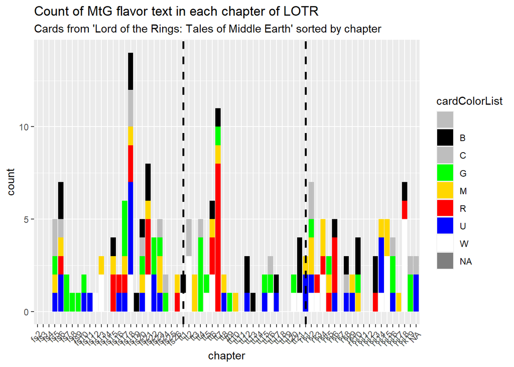

```r
tome_summary%>%
  ggplot(aes(x=chapter, y=count, fill=cardColorList))+
    geom_bar(stat="identity")+
    scale_fill_manual(values = c("gray", "black", "gray", "green", "gold", "red", "blue", "white"))+
    theme(axis.text.x = element_text(angle = 45, hjust = 1))+
    geom_vline(xintercept = "tt1", color = "black", size = 1, linetype = "dashed")+
    geom_vline(xintercept = "rk1", color = "black", size = 1, linetype = "dashed")+
  labs(title="Count of MtG flavor text in each chapter of LOTR",
       subtitle="Cards from 'Lord of the Rings: Tales of Middle Earth' sorted by chapter")
```

## Totals Per Color Per Chapter

This is the output I imported into my 3D model for tab placement.

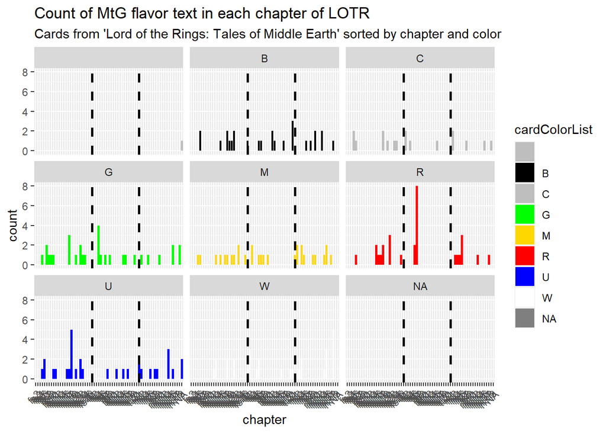

```r
tome_summary%>%
  ggplot(aes(x=chapter, y=count, fill=cardColorList))+
    geom_bar(stat="identity", position="dodge")+
    scale_fill_manual(values = c("gray", "black", "gray", "green", "gold", "red", "blue", "white"))+
    theme(axis.text.x = element_text(angle = 45, hjust = 1))+
    geom_vline(xintercept = "tt1", color = "black", size = 1, linetype = "dashed")+
    geom_vline(xintercept = "rk1", color = "black", size = 1, linetype = "dashed")+
    facet_wrap(~cardColorList)+
    labs(title="Count of MtG flavor text in each chapter of LOTR",
       subtitle="Cards from 'Lord of the Rings: Tales of Middle Earth' sorted by chapter and color")
```